# Student Retention and Machine Learning

Brayden Ross

February 15, 2019

## Introduction

This is a summary of the examination and implementation of machine learning applied to student retention at a higher-education, degree granting university. This analysis includes methods using decision tree/random forest modeling, as well as boosting and logistic regression.

The objective in this case was to be able to predict student dropout within the beginning two weeks of the following semester after the current enrollment using data extracted from the learning management system in use by the university. Normally, we would be concerned with the accuracy of the classification model. However, for our purposes, we were more concerned with the actual probabilities predicted. This allowed us to identify at risk students in comparison to all those enrolled vs. the default prediction threshold for classification.

## Data and Feature Extraction

The data housed in the learning management system was vast and useful. In previous analyses and implementations of tools, we were able to extract important metrics measuring course and instructor quality. They include, but are not limited to:

- Teacher-to-Student **Interactions** Per Student by Course
- **Login Counts** for Students and Instructors
- Total Student **Participation in Discussion Boards**
- Total Student **Submission Comments and Conversation Messages**

Using many of these already existing tools, we made use of the R package **dplyr** to transform and extract features from the data. An approach that was extremely beneficial in later analysis was to determine the fraction of the total interactions, submission comments, discussion posts and conversation messages in a course that each student was responsible for. For example, a student may have an average of 25% of the total discussion board posts in their courses.

After finding this proportion, mean, min and max functions were applied to all categories. This same approach was applied to determine the proportion of total interactions and posts for the instructors as well.

Another valuable insight was to examine the **quality** of courses the student had been enrolled in during their time at the university. This became tricky, initially the problem was approached by creating dummy variables for each individual course (over 1400). Assessing this method, it was decided that an approach with dimensionality reduction in mind was best. We tackled this by breaking the courses into levels by department, i.e. Accounting 1000 level courses, Biology 2000 level courses, and so forth. This reduced the dimensionality of the dataset considerably and still allowed us to identify the effect of number of quality courses taken by a student.

After doing so, we took the average of the categories mentioned above, and used those as a threshold of interactions for the respective departments and course levels. Using **bootstrapping** with 1000 iterations, we developed a standard error for this average, allowing for any anomalies in the courses and/or departments. After which, we assigned binary variables denoting whether a particular course had met or exceeded the average within the standard error in that category. For example, if the average for discussion board posts in Accounting 1000 level courses was 30.2, and accounting 1010 received 31.2 in a semester, they received a 1.

Using these features, we used dplyr once again to total the binary variables by student ID, showing how many courses over the course of their career at the university were at or above average. Students with low counts in these areas would most likely be recognized by the algorithm as having low-quality experiences, thereby being more likely to drop out/transfer.

The final, and perhaps most important method we used to maintain model accuracy while still ensuring time allotted to intervene with the student before dropout was to perform the analysis at early time periods in the semester. The two time periods examined for this analysis were at one month and six weeks into the respective semester of enrollment. These two time periods were chosen to determine whether there was a large difference in predictive power at week 4 vs. week 6 in addition to allowing the appropriate parties to reach out to the student and have time to remedy whatever impediments they may be having to retain them.

## Model Selection and Accuracy Examination

Preliminarily, 3 models were chosen to examine and use for analysis. They were boosting, using the incredibly accurate and powerful package [XGBoost](https://xgboost.readthedocs.io/en/latest/R-package/xgboostPresentation.html), decision tree forests using [Random Forests](https://cran.r-project.org/web/packages/randomForest/randomForest.pdf), and logistic regression.

To determine which models were most accurate, we wanted to ensure we not only examined accuracy rates amongst the three, but more importantly the ROC, more commonly known as AUC or Area-Under-Curve analysis. This would show us which models performed better across all thresholds rather than the base .5 used for classification algorithms. This is paramount to our rank order analysis, as the default parameter of .5 may exclude some students who are in the top percentile of at-risk individuals. Selecting a model using AUC analysis will remove this possibility and provide valuable insight to predictive power.

# Prediction Results

Let’s examine some of the results from our different predictive models. Keep in mind, that the accuracy of these models isn’t measured in predictive power, but in evaluating the AUC of the different models. The model with the greatest AUC is the one we should select, in order to have the best accuracy over differing cutoffs.

Examining the accuracy for cutoff graph, it seems like the XGB model (blue line) has a higher accuracy at a lower cutoff rating than random forest. So should we identify the optimal cutoff rate? As we mentioned before, this cutoff rate is ancillary and only needed if we really want to impose one. A rank-order analysis is optimal for our purposes here.

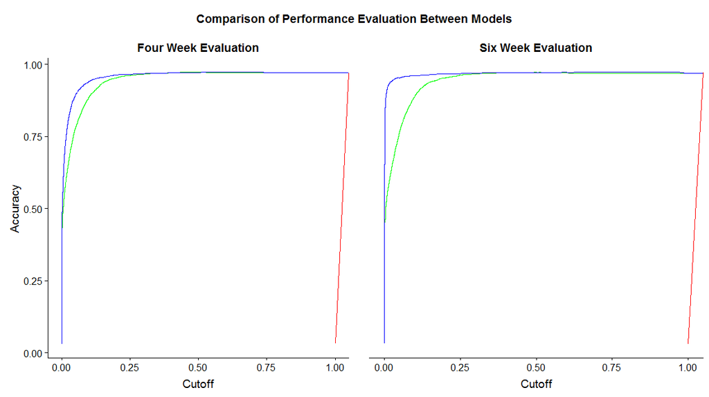

Now we can examine the most important aspect, the area-under-curve analysis. Examining the below graph, the logistic model hardly does better than making individual guesses as to whether the student will drop. But looking at the XGBoost model (blue line) and the Random Forest model (green line), its difficult to tell which does better overall, even between the four and six week subsets. Our logistic regression in both subsets performs terribly.

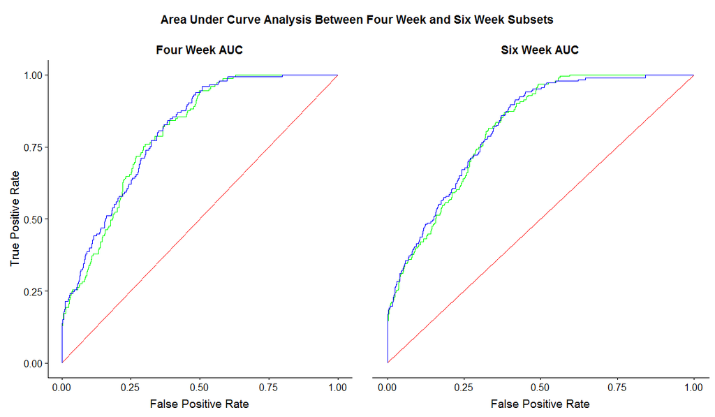

We can examine the actual area under curve using the wonderful tools included in the [ROCR](https://rocr.bioinf.mpi-sb.mpg.de/) and [pROC](https://cran.r-project.org/web/packages/pROC/index.html) packages. Below are the respective AUC values for each individual model, separated by four week and six week subsets:

Area Under Curve Four Week

| XGB AUC | RF AUC | LM AUC |
| --- | --- | --- |
| 0.8022574 | 0.7968702 | 0.5009229 |

Area Under Curve Six Week

| XGB AUC | RF AUC | LM AUC |
| --- | --- | --- |
| 0.8182148 | 0.816157 | 0.5007272 |

The difference between the XGB AUC and the Random Forest AUC is minimal in both 4 and 6 week subsets. This shows that between boosting and random forests, neither one is significantly better at predicting student dropouts. For purposes of interpretability and implementation, we chose random forest to use for this problem. The one drawback for using random forest is computational time and power, but this is ancillary for the time being.

# Final Predictive Example and Variable Importance

For the purpose of ample intervention time and predictability, the four week random forest prediction model was chosen.

Now that we’ve chosen our model, let’s take a look at our most important random forest variables:

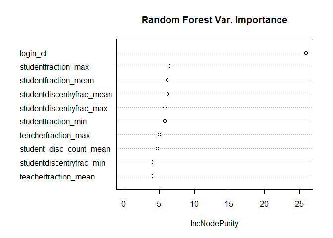

Wow! Login count seems to be incredibly important when predicting droupout. This makes sense as a student who isn’t logging in much would be prone to dropout as they are not turning in assignments or checking messages.

Some of the other important variables are:

- **studentfraction_mean** - This denotes the average fraction of interactions a student is responsible for in all their courses taken.
- **studentfraction_max** - This denotes the maximum fraction of interactions a student is responsible for in all their courses taken.
- **studentfraction_min** - This denotes the minimum fraction of interactions a student is responsible for in all their courses taken.
- **studentdiscentryfrac_mean** - This denotes the average fraction of discussion entries a student is responsible for in all their courses taken.

It seems to be a trend that interactions as a count are not as predictive as the fraction of interactions that a student or teacher are responsible for in a specific course. A student who has a higher average fraction of total interactions in more courses is much less likely to be at risk for dropping because they are involved and active in their classes. This is tells us that even if a student has high total interactions, those who have a low fraction of the total interactions may potentially be more at risk than average.

The correct implementation of this project is the most important aspect. Most institutions don’t have the resources to contact all those who are above average risk for dropout, so providing a sorted list of those most at risk is incredibly useful. Some may prefer a rank-order, starting from number one (most at risk) and decreasing from that point forward.

To visualize the output of the algorithm, we’ll sort the predictions from greatest to smallest. The top students are most at risk for dropout within the first two weeks of the following semester.

|  | Prediction | User ID |
| --- | --- | --- |
| 9933 | 0.8246667 | 2.146448e+17 |
| 15402 | 0.8080556 | 5.630213e+17 |
| 10414 | 0.8061111 | 2.437168e+17 |
| 6292 | 0.7619444 | -4.992332e+17 |
| 9011 | 0.7458889 | 1.560826e+17 |
| 1477 | 0.7074444 | -1.950927e+17 |
| 7060 | 0.6674444 | -5.490151e+17 |
| 7696 | 0.6458333 | -7.262097e+16 |
| 12525 | 0.6196667 | 3.843185e+17 |
| 5294 | 0.6182222 | -4.358169e+17 |

# Further Analysis and Improvements

This project is in preliminary implementation, meaning we have no results to show how the algorithm performs real time. These results will likely be available at the conclusion of this enrollment term (May 2019). The question of how to intervene is a much more administration-oriented problem. Therefore, by providing the results to those who can use them, we’ve provided the best possible tools. After the end of the current enrollment term, the model and its performance will be re-assessed and tuned as needed.

As far as improvments to the model, additional explanatory data would be very useful. At the time of implementation, data access was limited. Things that would be incredibly informational are as follows:

- High School GPA
- Current College GPA (If available)
- Financial Aid Status
- ACT/SAT Score
- Class Standing
- Declared Major

It seems as if these would be obvious variables to include (which they are), but due to administrative blocks and delays, this data was not made available for this project. Currently we are working to obtain this, and will update the model at the appropriate times.

Thank you for reading the kernel, any and all questions can be directed to brayden.d.ross@gmail.com.